# Wassertein Generative Adversarial Network

This part is an evolution of the previous GAN model. The main difference is that this time the loss function is a Wassertein loss. This addresses some of the limitations of the first mode, in particular the instability of training.

Why? In the previous GAN, the generator and the discriminator are trained using the binary cross-entropy loss, which has the following problems:

- **Vanishing gradient**: when the discriminator becomes too "confident", the generator receives no useful information to improve.
- **Training instability**: losses doesn't seem to decrease due to the saturating nature of the sigmoid and BCE.

WGAN uses a critic that outputs real values (not probabilities), and optimizes and optimizes:

- **Critic (Discriminator) loss:**

  $$ \mathcal{L}_D = \mathbb{E}_{\mathbf{\tilde{x}} \sim \mathbb{P}_g} [D(\tilde{x})] - \mathbb{E}_{\mathbf{x} \sim \mathbb{P}_r} [D(x)] $$

  The critic tries to maximize the difference between its output on fake data $\tilde{x}$ and real data $x$.
- **Generator loss:**

  $$ \mathcal{L}_G = - \mathbb{E}_{\mathbf{\tilde{x}} \sim \mathbb{P}_g} [D(\tilde{x})] $$

## Setting up the GAN

This first part is the one commented in the basic GAN and the same reasoning for the VAE holds

```python
import pandas as pd
import numpy as np
import torch
import torch.nn as nn
from torch.utils.data import DataLoader, TensorDataset
import torch.nn.functional as F
import matplotlib.pyplot as plt
from sklearn.preprocessing import MinMaxScaler
from sklearn.metrics import mean_squared_error
import math
```

```python
file_path = './Dataset3_PortfolioReplicaStrategy.xlsx'


data_raw = pd.read_excel(file_path)


# Set the date column as the index and ensure it's in datetime format
data_raw['Date'] = pd.to_datetime(data_raw['Ticker'], format='%d/%m/%Y')
data = data_raw.set_index('Date')

# Display the first few rows to examine the dataset structure
print("Dataset preview:")
display(data.head())

# Show the variable information (Ticker -> Full Name)
print("\nVariable Information (Bloomberg Ticker -> Full Name):")

# Show basic information about the dataset
print("\nDataset information:")
display(data.info())

# Display statistical summary of the dataset
print("\nBasic statistics:")
display(data.describe())
```

```
Dataset preview:
```

| Date | Ticker | MXWO | MXWD | LEGATRUU | HFRXGL | RX1 | TY1 | GC1 | CO1 | ES1 | VG1 | NQ1 | LLL1 | TP1 | DU1 | TU2 |
| --- | --- | --- | --- | --- | --- | --- | --- | --- | --- | --- | --- | --- | --- | --- | --- | --- |
| 2007-10-23 | 2007-10-23 | 1633.44 | 414.14 | 350.2138 | 1343.63 | 113.70 | 110.515625 | 759.0 | 82.85 | 1525.50 | 4393.0 | 2212.00 | 1287.0 | 1570.5 | 103.385 | 103.718750 |
| 2007-10-30 | 2007-10-30 | 1663.89 | 423.26 | 352.5413 | 1356.53 | 113.79 | 110.656250 | 787.8 | 87.44 | 1536.00 | 4476.0 | 2217.75 | 1323.9 | 1610.5 | 103.410 | 103.812500 |
| 2007-11-06 | 2007-11-06 | 1651.59 | 419.51 | 354.1758 | 1360.20 | 113.79 | 110.875000 | 823.4 | 93.26 | 1525.00 | 4425.0 | 2233.50 | 1320.0 | 1575.5 | 103.410 | 104.046875 |
| 2007-11-13 | 2007-11-13 | 1601.81 | 405.98 | 357.2217 | 1347.16 | 114.35 | 111.718750 | 799.0 | 88.83 | 1483.25 | 4323.0 | 2066.75 | 1271.0 | 1440.5 | 103.595 | 104.304688 |
| 2007-11-20 | 2007-11-20 | 1570.74 | 398.54 | 359.4446 | 1335.21 | 114.72 | 113.156250 | 791.4 | 95.49 | 1446.00 | 4296.0 | 2035.50 | 1225.2 | 1472.5 | 103.800 | 104.945312 |

```
Variable Information (Bloomberg Ticker -> Full Name):

Dataset information:
<class 'pandas.core.frame.DataFrame'>
DatetimeIndex: 705 entries, 2007-10-23 to 2021-04-20
Data columns (total 16 columns):
 #   Column    Non-Null Count  Dtype
---  ------    --------------  -----
 0   Ticker    705 non-null    datetime64[ns]
 1   MXWO      705 non-null    float64
 2   MXWD      705 non-null    float64
 3   LEGATRUU  705 non-null    float64
 4   HFRXGL    705 non-null    float64
 5   RX1       705 non-null    float64
 6   TY1       705 non-null    float64
 7   GC1       705 non-null    float64
 8   CO1       705 non-null    float64
 9   ES1       705 non-null    float64
 10  VG1       705 non-null    float64
 11  NQ1       705 non-null    float64
 12  LLL1      705 non-null    float64
 13  TP1       705 non-null    float64
 14  DU1       705 non-null    float64
 15  TU2       705 non-null    float64
dtypes: datetime64[ns](1), float64(15)
memory usage: 93.6 KB
```

```
None
```

```
Basic statistics:
```

|  | MXWO | MXWD | LEGATRUU | HFRXGL | RX1 | TY1 | GC1 | CO1 | ES1 | VG1 | NQ1 | LLL1 | TP1 | DU1 | TU2 |
| --- | --- | --- | --- | --- | --- | --- | --- | --- | --- | --- | --- | --- | --- | --- | --- |
| count | 705.00000 | 705.000000 | 705.000000 | 705.000000 | 705.000000 | 705.000000 | 705.000000 | 705.000000 | 705.000000 | 705.000000 | 705.000000 | 705.000000 | 705.000000 | 705.000000 | 705.000000 |
| mean | 1644.12566 | 404.151915 | 452.203206 | 1210.092071 | 147.278837 | 125.966977 | 1317.902837 | 77.018496 | 1960.443050 | 3072.167631 | 4526.981206 | 1064.444113 | 1277.263121 | 110.221277 | 108.627682 |
| std | 443.39041 | 100.980126 | 47.338067 | 73.965200 | 19.318527 | 6.295242 | 274.477979 | 26.794278 | 770.070634 | 473.812729 | 2900.866833 | 128.954655 | 353.598276 | 2.374875 | 1.532632 |
| min | 705.35000 | 176.100000 | 342.247100 | 1021.400000 | 110.200000 | 110.515625 | 732.700000 | 19.330000 | 689.500000 | 1873.000000 | 1072.000000 | 465.100000 | 704.000000 | 102.190000 | 103.718750 |
| 25% | 1293.43000 | 328.790000 | 431.737400 | 1158.150000 | 128.900000 | 121.203125 | 1178.000000 | 54.270000 | 1314.500000 | 2753.000000 | 2244.000000 | 1103.600000 | 905.000000 | 109.230000 | 107.871094 |
| 50% | 1646.69000 | 402.570000 | 456.728800 | 1215.200000 | 148.000000 | 126.000000 | 1283.000000 | 72.050000 | 1909.250000 | 3071.000000 | 3884.750000 | 1103.600000 | 1302.500000 | 110.855000 | 109.093750 |
| 75% | 1978.83000 | 478.410000 | 478.186800 | 1254.250000 | 163.240000 | 130.343750 | 1499.700000 | 105.780000 | 2569.750000 | 3433.000000 | 6333.250000 | 1103.600000 | 1587.500000 | 111.990000 | 109.906250 |
| max | 2944.05000 | 702.990000 | 559.311700 | 1415.110000 | 179.320000 | 140.328125 | 2001.200000 | 140.670000 | 4132.800000 | 4476.000000 | 13975.750000 | 1323.900000 | 1978.000000 | 112.720000 | 110.527344 |

```python
found_index=['MXWO','MXWD','LEGATRUU','HFRXGL']
futures=data.drop(columns=found_index)
found_index=['Ticker','MXWO','MXWD','LEGATRUU','HFRXGL']
hedge_fd=data.loc[:,found_index]

#Creation of a monster index
dates=hedge_fd.iloc[:,0]
#Getting the notmalized prices of the hedge founds
prices_hf=hedge_fd.iloc[:,1:]/hedge_fd.iloc[0,1:] #normalized prices
initial_price=hedge_fd.iloc[0,1:]

#Calculate the returns
returns = (hedge_fd.iloc[1:, 1:].values/ hedge_fd.iloc[:-1, 1:].values) - 1
returns = pd.DataFrame(returns, columns=hedge_fd.columns[1:])

#Creation of a Monster indexa
w_MXWO=0.25
w_LEGATRUU=0.25
w_HFRXGL=0.5

#Computing normalized prices and prices of our Monster Index
y_price=w_MXWO*hedge_fd.iloc[:,1]+w_LEGATRUU*hedge_fd.iloc[:,2]+w_HFRXGL*hedge_fd.iloc[:,3]
y_values = pd.DataFrame(y_price, columns=['Target'])
y_price=y_values/y_values.iloc[0]
#Computing returns of our monster index
returns_MI = (y_price.iloc[1:].values/ y_price.iloc[:-1].values) - 1
returns_MI = pd.DataFrame(returns_MI, columns=['Target'])
returns_MI['Target'] = pd.to_numeric(returns_MI['Target'] , errors='coerce')

#Futures Prices & Returns
returns_futures = (futures.iloc[1:, 1:].values/ futures.iloc[:-1, 1:].values) - 1
returns_futures = pd.DataFrame(returns_futures, columns=futures.columns[1:])
price_futures=futures.iloc[:,1:]
price_futures_std=futures.iloc[:,1:]/futures.iloc[0,1:] #normalized prices of futures

returns_futures=returns_futures.drop(columns=['LLL1'])
returns_futures=returns_futures.drop(columns=['NQ1'])
```

```python
y = y_price.values
x = price_futures_std.values
x.shape, y.shape
```

```
((705, 11), (705, 1))
```

```python
split = int(data.shape[0]* 0.8)
train_x, test_x = x[: split, :], x[split - 20:, :]
train_y, test_y = y[: split, ], y[split - 20: , ]

print(f'trainX: {train_x.shape} trainY: {train_y.shape}')
print(f'testX: {test_x.shape} testY: {test_y.shape}')

x_scaler = MinMaxScaler(feature_range = (0, 1))
y_scaler = MinMaxScaler(feature_range = (0, 1))

train_x = x_scaler.fit_transform(train_x)
test_x = x_scaler.transform(test_x)

train_y = y_scaler.fit_transform(train_y.reshape(-1, 1))
test_y = y_scaler.transform(test_y.reshape(-1, 1))
```

```
trainX: (564, 11) trainY: (564, 1)
testX: (161, 11) testY: (161, 1)
```

```python
class VAE(nn.Module):
    def __init__(self, config, latent_dim):
        super().__init__()

        modules = []
        for i in range(1, len(config)):
            modules.append(
                nn.Sequential(
                    nn.Linear(config[i - 1], config[i]),
                    nn.ReLU()
                )
            )

        self.encoder = nn.Sequential(*modules)
        self.fc_mu = nn.Linear(config[-1], latent_dim)
        self.fc_var = nn.Linear(config[-1], latent_dim)

        modules = []
        self.decoder_input = nn.Linear(latent_dim, config[-1])

        for i in range(len(config) - 1, 1, -1):
            modules.append(
                nn.Sequential(
                    nn.Linear(config[i], config[i - 1]),
                    nn.ReLU()
                )
            )
        modules.append(
            nn.Sequential(
                nn.Linear(config[1], config[0]),
                nn.Sigmoid()
            )
        )

        self.decoder = nn.Sequential(*modules)

    def encode(self, x):
        result = self.encoder(x)
        mu = self.fc_mu(result)
        logVar = self.fc_var(result)
        return mu, logVar

    def decode(self, x):
        result = self.decoder(x)
        return result

    def reparameterize(self, mu, logVar):
        std = torch.exp(0.5* logVar)
        eps = torch.randn_like(std)
        return eps * std + mu

    def forward(self, x):
        mu, logVar = self.encode(x)
        z = self.reparameterize(mu, logVar)
        output = self.decode(z)
        return output, z, mu, logVar
```

```python
train_loader = DataLoader(TensorDataset(torch.from_numpy(train_x).float()), batch_size = 128, shuffle = False)
model = VAE([11, 400, 400, 400, 10], 10)
```

```python
use_cuda = 1
device = torch.device("cuda" if (torch.cuda.is_available() & use_cuda) else "cpu")
num_epochs = 300
learning_rate = 0.00003
model = model.to(device)
optimizer = torch.optim.Adam(model.parameters(), lr = learning_rate)

hist = np.zeros(num_epochs)
for epoch in range(num_epochs):
    total_loss = 0
    loss_ = []
    for (x, ) in train_loader:
        x = x.to(device)
        output, z, mu, logVar = model(x)
        kl_divergence = 0.5* torch.sum(-1 - logVar + mu.pow(2) + logVar.exp())
        loss = F.binary_cross_entropy(output, x) + kl_divergence
        loss.backward()
        optimizer.step()
        loss_.append(loss.item())
    hist[epoch] = sum(loss_)
    print('[{}/{}] Loss:'.format(epoch+1, num_epochs), sum(loss_))
```

```
[1/300] Loss: 28.049540519714355
[2/300] Loss: 28.071685791015625
[3/300] Loss: 28.09993553161621
[4/300] Loss: 28.12515163421631
[5/300] Loss: 28.145391702651978
[6/300] Loss: 28.15734553337097
[7/300] Loss: 28.157588720321655
[8/300] Loss: 28.145339012145996
[9/300] Loss: 28.115719318389893
[10/300] Loss: 28.070844650268555
[11/300] Loss: 28.007264852523804
[12/300] Loss: 27.927878856658936
[13/300] Loss: 27.829294443130493
[14/300] Loss: 27.715167999267578
[15/300] Loss: 27.5845627784729
[16/300] Loss: 27.441631317138672
[17/300] Loss: 27.286404609680176
[18/300] Loss: 27.122018575668335
[19/300] Loss: 26.95243549346924
[20/300] Loss: 26.77852487564087
[21/300] Loss: 26.602853775024414
[22/300] Loss: 26.43092679977417
[23/300] Loss: 26.260560035705566
[24/300] Loss: 26.098319053649902
[25/300] Loss: 25.943933248519897
[26/300] Loss: 25.79995083808899
[27/300] Loss: 25.6664137840271
[28/300] Loss: 25.544949293136597
[29/300] Loss: 25.438862800598145
[30/300] Loss: 25.345871925354004
[31/300] Loss: 25.26682686805725
[32/300] Loss: 25.200477838516235
[33/300] Loss: 25.148471355438232
[34/300] Loss: 25.109110355377197
[35/300] Loss: 25.081135988235474
[36/300] Loss: 25.06544327735901
[37/300] Loss: 25.05768346786499
[38/300] Loss: 25.05507254600525
[39/300] Loss: 25.062557458877563
[40/300] Loss: 25.072254180908203
```

[output cut: 245 more lines]

```
[286/300] Loss: 10.662183403968811
[287/300] Loss: 10.608994126319885
[288/300] Loss: 10.556723594665527
[289/300] Loss: 10.506754398345947
[290/300] Loss: 10.458618640899658
[291/300] Loss: 10.412045240402222
[292/300] Loss: 10.368321180343628
[293/300] Loss: 10.32563066482544
[294/300] Loss: 10.287245988845825
[295/300] Loss: 10.249264240264893
[296/300] Loss: 10.21580696105957
[297/300] Loss: 10.181930661201477
[298/300] Loss: 10.152495622634888
[299/300] Loss: 10.124747633934021
[300/300] Loss: 10.098002910614014
```

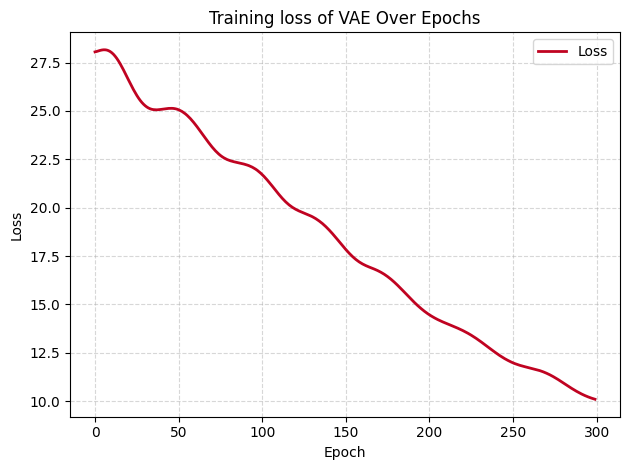

```python
monster_red = "#C00321"
plt.figure()
plt.plot(hist, label='Loss', linewidth=2, color=monster_red)
plt.xlabel('Epoch')
plt.ylabel('Loss')
plt.title('Training loss of VAE Over Epochs')
plt.legend(frameon=True)
plt.grid(True, linestyle='--', alpha=0.5)
plt.tight_layout()
```

```python
model.eval()
_, VAE_train_x, train_x_mu, train_x_var = model(torch.from_numpy(train_x).float().to(device))
_, VAE_test_x, test_x_mu, test_x_var = model(torch.from_numpy(test_x).float().to(device))
```

```python
def sliding_window(x, y, window):
    x_ = []
    y_ = []
    y_gan = []
    for i in range(window, x.shape[0]):
        tmp_x = x[i - window: i, :]
        tmp_y = y[i]
        tmp_y_gan = y[i - window: i + 1]
        x_.append(tmp_x)
        y_.append(tmp_y)
        y_gan.append(tmp_y_gan)
    x_ = torch.from_numpy(np.array(x_)).float()
    y_ = torch.from_numpy(np.array(y_)).float()
    y_gan = torch.from_numpy(np.array(y_gan)).float()
    return x_, y_, y_gan
```

```python
train_x = np.concatenate((train_x, VAE_train_x.cpu().detach().numpy()), axis = 1)
test_x = np.concatenate((test_x, VAE_test_x.cpu().detach().numpy()), axis = 1)
```

```python
train_x_slide, train_y_slide, train_y_gan = sliding_window(train_x, train_y, 3)
test_x_slide, test_y_slide, test_y_gan = sliding_window(test_x, test_y, 3)
print(f'train_x: {train_x_slide.shape} train_y: {train_y_slide.shape} train_y_gan: {train_y_gan.shape}')
print(f'test_x: {test_x_slide.shape} test_y: {test_y_slide.shape} test_y_gan: {test_y_gan.shape}')
```

```
train_x: torch.Size([561, 3, 21]) train_y: torch.Size([561, 1]) train_y_gan: torch.Size([561, 4, 1])
test_x: torch.Size([158, 3, 21]) test_y: torch.Size([158, 1]) test_y_gan: torch.Size([158, 4, 1])
```

## Setting up the WGAN

The same structure as for the baseline model is chosen for the generator and for the discrimator.

```python
class Generator(nn.Module):
    def __init__(self, input_size):
        super().__init__()
        self.gru_1 = nn.GRU(input_size, 1024, batch_first = True)
        self.gru_2 = nn.GRU(1024, 512, batch_first = True)
        self.gru_3 = nn.GRU(512, 256, batch_first = True)
        self.linear_1 = nn.Linear(256, 128)
        self.linear_2 = nn.Linear(128, 64)
        self.linear_3 = nn.Linear(64, 1)
        self.dropout = nn.Dropout(0.2)


    def forward(self, x):
        use_cuda = 1
        device = torch.device("cuda" if (torch.cuda.is_available() & use_cuda) else "cpu")
        h0 = torch.zeros(1, x.size(0), 1024).to(device)
        out_1, _ = self.gru_1(x, h0)
        out_1 = self.dropout(out_1)
        h1 = torch.zeros(1, x.size(0), 512).to(device)
        out_2, _ = self.gru_2(out_1, h1)
        out_2 = self.dropout(out_2)
        h2 = torch.zeros(1, x.size(0), 256).to(device)
        out_3, _ = self.gru_3(out_2, h2)
        out_3 = self.dropout(out_3)
        out_4 = self.linear_1(out_3[:, -1, :])
        out_5 = self.linear_2(out_4)
        out_6 = self.linear_3(out_5)
        return out_6

class Discriminator(nn.Module):
    def __init__(self):
        super().__init__()
        self.conv1 = nn.Conv1d(4, 32, kernel_size = 5, stride = 1, padding = 'same')
        self.conv2 = nn.Conv1d(32, 64, kernel_size = 5, stride = 1, padding = 'same')
        self.conv3 = nn.Conv1d(64, 128, kernel_size = 5, stride = 1, padding = 'same')
        self.linear1 = nn.Linear(128, 220)
        self.linear2 = nn.Linear(220, 220)
        self.linear3 = nn.Linear(220, 1)
        self.leaky = nn.LeakyReLU(0.01)
        self.relu = nn.ReLU()

    def forward(self, x):
        conv1 = self.conv1(x)
        conv1 = self.leaky(conv1)
        conv2 = self.conv2(conv1)
        conv2 = self.leaky(conv2)
        conv3 = self.conv3(conv2)
        conv3 = self.leaky(conv3)
        flatten_x =  conv3.reshape(conv3.shape[0], conv3.shape[1])
        out_1 = self.linear1(flatten_x)
        out_1 = self.leaky(out_1)
        out_2 = self.linear2(out_1)
        out_2 = self.relu(out_2)
        out = self.linear3(out_2)
        return out
```

## WGAN Training

This following piece of code trains the WGAN and for it to work it needs of the following values:

- **Multiple critic updates (`n_critic=5`):** For each generator update, the critic (discriminator) is updated multiple times to better approximate the Wasserstein distance.
- **Weight clipping (`clip_value=0.5`):** Applied to critic parameters to enforce the Lipschitz constraint required by WGAN theory, preventing the critic from becoming too "steep" and ensuring stable training.

This values are up for optimization and if those are changed the results differ by a lot.

```python
# Impostazioni base
use_cuda = 1
device = torch.device("cuda" if (torch.cuda.is_available() & use_cuda) else "cpu")

batch_size = 128
learning_rate = 0.00015
num_epochs = 200
n_critic = 5  # numero di aggiornamenti del critic per ogni passo del generatore
clip_value = 0.5  # clipping dei pesi del critic

# Dataloader
trainDataloader = DataLoader(
    TensorDataset(train_x_slide, train_y_gan),
    batch_size=batch_size,
    shuffle=False
)

# Modelli
modelG = Generator(21).to(device)
modelD = Discriminator().to(device)

optimizerG = torch.optim.RMSprop(modelG.parameters(), lr=learning_rate)
optimizerD = torch.optim.RMSprop(modelD.parameters(), lr=learning_rate)

histG = np.zeros(num_epochs)
histD = np.zeros(num_epochs)

for epoch in range(num_epochs):
    loss_G_epoch = []
    loss_D_epoch = []

    for i, (x, y) in enumerate(trainDataloader):
        x = x.to(device)
        y = y.to(device)

        for _ in range(n_critic):

            fake_data = modelG(x).detach()
            fake_data = torch.cat([y[:, :3, :], fake_data.reshape(-1, 1, 1)], dim=1)

            # Calcola output del critic
            dis_real_output = modelD(y)
            dis_fake_output = modelD(fake_data)

            # Wasserstein loss
            lossD = -torch.mean(dis_real_output) + torch.mean(dis_fake_output)

            modelD.zero_grad()
            lossD.backward()
            optimizerD.step()

            for p in modelD.parameters():
                p.data.clamp_(-clip_value, clip_value)

        loss_D_epoch.append(lossD.item())

        fake_data = modelG(x)
        fake_data = torch.cat([y[:, :3, :], fake_data.reshape(-1, 1, 1)], dim=1)

        output_fake = modelD(fake_data)

        lossG = -torch.mean(output_fake)

        modelG.zero_grad()
        lossG.backward()
        optimizerG.step()

        loss_G_epoch.append(lossG.item())

    histG[epoch] = sum(loss_G_epoch)
    histD[epoch] = sum(loss_D_epoch)
    print(f'[{epoch+1}/{num_epochs}] LossD: {histD[epoch]:.4f}  LossG: {histG[epoch]:.4f}')
```

```
[1/200] LossD: -0.0261  LossG: 0.3570
[2/200] LossD: -0.0136  LossG: 0.3464
[3/200] LossD: -0.0104  LossG: 0.3305
[4/200] LossD: -0.0229  LossG: 0.3373
[5/200] LossD: -0.0484  LossG: 0.3210
[6/200] LossD: -0.5988  LossG: 0.4962
[7/200] LossD: -0.6931  LossG: 0.3676
[8/200] LossD: -1.0231  LossG: 0.0637
[9/200] LossD: -1.6335  LossG: -0.0050
[10/200] LossD: -1.9402  LossG: 0.1186
[11/200] LossD: -2.6818  LossG: 0.2422
[12/200] LossD: -3.5061  LossG: -0.4277
[13/200] LossD: -5.0195  LossG: 0.0192
[14/200] LossD: -7.6496  LossG: 1.1112
[15/200] LossD: -9.4602  LossG: 0.5912
[16/200] LossD: -27.2541  LossG: 9.7052
[17/200] LossD: -27.7976  LossG: 1.9412
[18/200] LossD: -28.4502  LossG: -2.7573
[19/200] LossD: -43.5876  LossG: 5.7649
[20/200] LossD: -42.5734  LossG: -1.9698
[21/200] LossD: -85.9933  LossG: 17.1510
[22/200] LossD: -97.4699  LossG: 9.4021
[23/200] LossD: -112.4045  LossG: 4.2413
[24/200] LossD: -104.5922  LossG: -14.9483
[25/200] LossD: -155.6459  LossG: 0.2302
[26/200] LossD: -146.6192  LossG: -40.0920
[27/200] LossD: -182.9191  LossG: -11.8805
[28/200] LossD: -230.7397  LossG: -3.4181
[29/200] LossD: -116.1930  LossG: -136.4576
[30/200] LossD: -206.9706  LossG: -67.8212
[31/200] LossD: -262.6455  LossG: -62.1349
[32/200] LossD: -243.6528  LossG: -153.4534
[33/200] LossD: -341.4625  LossG: -51.0287
[34/200] LossD: -225.0326  LossG: -195.8407
[35/200] LossD: -316.6183  LossG: -142.9332
[36/200] LossD: -477.2750  LossG: -54.6785
[37/200] LossD: -409.1248  LossG: -212.5887
[38/200] LossD: -341.0522  LossG: -338.5369
[39/200] LossD: -347.1305  LossG: -330.1549
[40/200] LossD: -185.0797  LossG: -466.9605
```

[output cut: 145 more lines]

```
[186/200] LossD: -72891.3818  LossG: -28751.8524
[187/200] LossD: -49771.4678  LossG: -49820.5198
[188/200] LossD: -50468.3887  LossG: -57742.2896
[189/200] LossD: -49921.9707  LossG: -53292.3384
[190/200] LossD: -34541.3418  LossG: -65621.1201
[191/200] LossD: -50399.0967  LossG: -49517.1631
[192/200] LossD: -64779.4531  LossG: -45949.4610
[193/200] LossD: -63617.4531  LossG: -40586.5952
[194/200] LossD: -53472.3086  LossG: -49404.3325
[195/200] LossD: -45829.7578  LossG: -58530.0425
[196/200] LossD: -53859.0762  LossG: -52446.3945
[197/200] LossD: -38919.9473  LossG: -74280.2363
[198/200] LossD: -74997.6914  LossG: -30825.4129
[199/200] LossD: -43157.8848  LossG: -74228.8926
[200/200] LossD: -70861.9932  LossG: -38310.6621
```

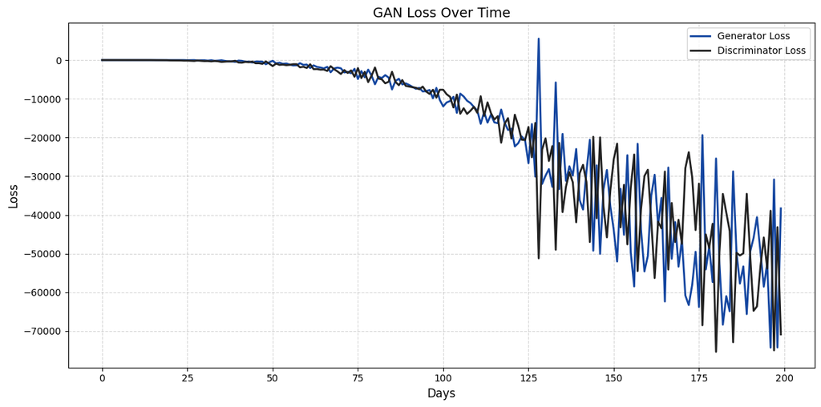

```python
gen_color = "#1446A0"
disc_color = "#222222"
plt.figure(figsize=(12, 6))
plt.plot(histG, color=gen_color, label='Generator Loss', linewidth=2)
plt.plot(histD, color=disc_color, label='Discriminator Loss', linewidth=2)
plt.title('GAN Loss Over Time', fontsize=14)
plt.xlabel('Days', fontsize=12)
plt.ylabel('Loss', fontsize=12)
plt.legend(loc='upper right', frameon=True)
plt.grid(True, linestyle='--', alpha=0.5)
plt.tight_layout()
```

Unlike in the baseline GAN this time the WGAN loss is decreasing even if in a noisy way.

```python
modelG.eval()
pred_y_train = modelG(train_x_slide.to(device))
pred_y_test = modelG(test_x_slide.to(device))

y_train_true = y_scaler.inverse_transform(train_y_slide)
y_train_pred = y_scaler.inverse_transform(pred_y_train.cpu().detach().numpy())

y_test_true = y_scaler.inverse_transform(test_y_slide)
y_test_pred = y_scaler.inverse_transform(pred_y_test.cpu().detach().numpy())
```

```
Training dataset RMSE: 0.0340
```

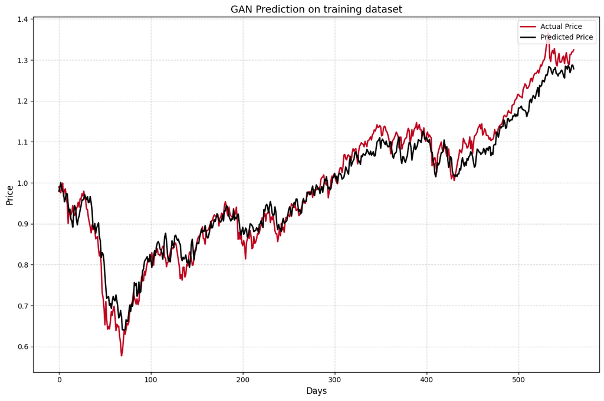

```python
actual_color = "#C00321"
pred_color = "#000000"
plt.figure(figsize=(12, 8))
plt.plot(y_train_true, color=actual_color, label='Actual Price', linewidth=2)
plt.plot(y_train_pred, color=pred_color, label='Predicted Price', linewidth=2)
plt.title('GAN Prediction on training dataset', fontsize=14)
plt.xlabel('Days', fontsize=12)
plt.ylabel('Price', fontsize=12)
plt.legend(loc='upper right', frameon=True)
plt.grid(True, linestyle='--', alpha=0.5)
plt.tight_layout()
MSE = mean_squared_error(y_train_true, y_train_pred)
RMSE = math.sqrt(MSE)
print(f'Training dataset RMSE: {RMSE:.4f}')
```

## Testing WGAN

```
Testing dataset RMSE: 0.1119
```

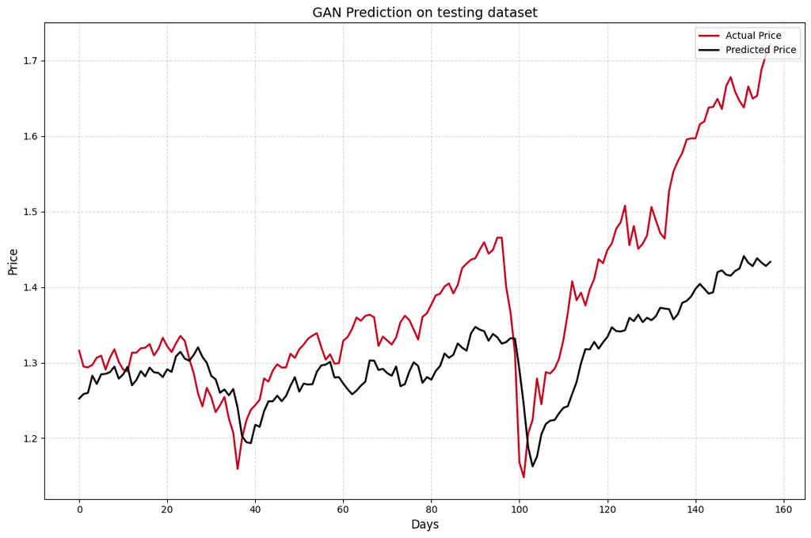

```python
plt.figure(figsize=(12, 8))
plt.plot(y_test_true, color=actual_color, label='Actual Price', linewidth=2)
plt.plot(y_test_pred, color=pred_color, label='Predicted Price', linewidth=2)
plt.title('GAN Prediction on testing dataset', fontsize=14)
plt.xlabel('Days', fontsize=12)
plt.ylabel('Price', fontsize=12)
plt.legend(loc='upper right', frameon=True)
plt.grid(True, linestyle='--', alpha=0.5)
plt.tight_layout()
MSE = mean_squared_error(y_test_true, y_test_pred)
RMSE = math.sqrt(MSE)
print(f'Testing dataset RMSE: {RMSE:.4f}')
```

Comparing these results with the one obtained with the baseline model, we see that the RMSE decrease both in the training and in the test set by approximately $20\%$ which is impressive. The RMSE on the training set is much lower than the one for the testing set meaning maybe a little overfitting even though nothing dramatic.

```
Average Historical VaR 95%: 0.0195
Average Historical VaR 99% (last point): 0.0251
```

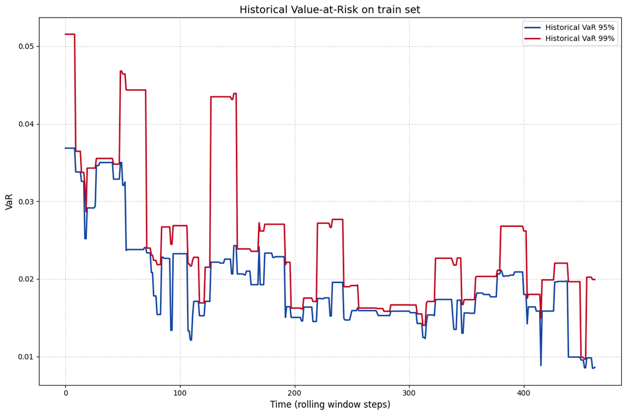

```python
rolling = 48
Returns1 = (y_train_pred[rolling+1:] / y_train_pred[rolling:-1]) - 1
SampleSize = len(Returns1)

pVAR = [0.05, 0.01]

Historical95 = []
Historical99 = []
EstimationWindowSize = int(rolling / 2)

for t in range(rolling + 1, len(Returns1)):
    y = Returns1[(t - EstimationWindowSize):(t-1)]

    Historical95.append(np.quantile(y, 0.95))
    Historical99.append(np.quantile(y, 0.99))

plt.figure(figsize=(12, 8))

plt.plot(Historical95, label='Historical VaR 95%', linewidth=2, color="#1446A0")
plt.plot(Historical99, label='Historical VaR 99%', linewidth=2, color="#C00321")

plt.title('Historical Value-at-Risk on train set', fontsize=14)
plt.xlabel('Time (rolling window steps)', fontsize=12)
plt.ylabel('VaR', fontsize=12)

plt.legend(loc='upper right', frameon=True)
plt.grid(True, linestyle='--', alpha=0.5)
plt.tight_layout()
print(f'Average Historical VaR 95%: {np.mean(Historical95):.4f}')
print(f'Average Historical VaR 99% (last point): {np.mean(Historical99):.4f}')
```

```
Average Historical VaR 95% (last point): 0.0134
Average Historical VaR 99% (last point): 0.0158
```

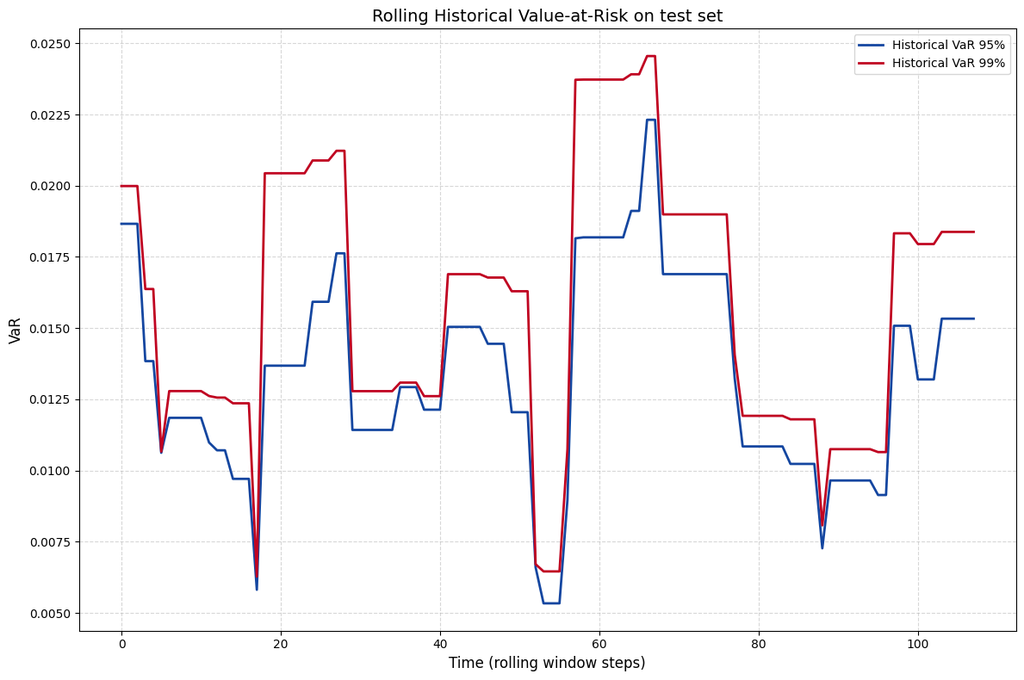

```python
rolling = 24
Returns1 = (y_test_pred[rolling+1:] / y_test_pred[rolling:-1]) - 1
SampleSize = len(Returns1)

pVAR = [0.05, 0.01]

Historical95 = []
Historical99 = []
EstimationWindowSize = int(rolling / 2)

for t in range(rolling + 1, len(Returns1)):
    y = Returns1[(t - EstimationWindowSize):(t-1)]

    Historical95.append(np.quantile(y, 0.95))
    Historical99.append(np.quantile(y, 0.99))

plt.figure(figsize=(12, 8))

plt.plot(Historical95, label='Historical VaR 95%', linewidth=2, color="#1446A0")
plt.plot(Historical99, label='Historical VaR 99%', linewidth=2, color="#C00321")

plt.title('Rolling Historical Value-at-Risk on test set', fontsize=14)
plt.xlabel('Time (rolling window steps)', fontsize=12)
plt.ylabel('VaR', fontsize=12)

plt.legend(loc='upper right', frameon=True)
plt.grid(True, linestyle='--', alpha=0.5)
plt.tight_layout()

# Print last-point averages
print(f'Average Historical VaR 95% (last point): {np.mean(Historical95):.4f}')
print(f'Average Historical VaR 99% (last point): {np.mean(Historical99):.4f}')
```

By adopting a more complex model what we see is that we have a lower Value at Risk. The following result can be explained by:

- WGANs provide more informative gradients, leading to better convergence. This helps the generator learn the true data distribution more accurately, reducing the generation of unrealistically extreme returns that would otherwise inflate VaR.
- Since VaR is a quantile-based measure (typically 95% or 99%), it is highly sensitive to the distribution's tails. WGAN-generated returns tend to follow the statistical properties of real data more closely, especially in the tails, leading to a tighter (i.e., lower risk) estimate of VaR.